# Workplace EDA

```r
library(dplyr)
library(ggplot2)
library(tidyr)

library(tidyr)
```

```r
gender_inequality_and_economic_indicators_dataset <- read.csv("data/processed-data/gender_inequality_and_economic_indicators_dataset_clean_final.csv")
head(gender_inequality_and_economic_indicators_dataset)
```

```
              Economy Economy.Code ISO.Code                     Region
1         afghanistan          AFG      AFG                 South Asia
2             albania          ALB      ALB      Europe & Central Asia
3             algeria          DZA      DZA Middle East & North Africa
4              angola          AGO      AGO         Sub-Saharan Africa
5 antigua and barbuda          ATG      ATG  Latin America & Caribbean
6           argentina          ARG      ARG  Latin America & Caribbean
         Income.Group Report.Year WBL.INDEX MOBILITY
1          Low income        2018      38.1       50
2 Upper middle income        2018      91.3      100
3 Lower middle income        2018      57.5       75
4 Lower middle income        2018      73.1      100
5         High income        2018      66.3       75
6 Upper middle income        2018      73.1      100
  Can.a.woman.choose.where.to.live.in.the.same.way.as.a.man.
```

[output cut: 279 more lines]

```r
economic_indicators_and_gender_inequality_data_subset <- gender_inequality_and_economic_indicators_dataset%>%
  select(Economy,
Economy.Code,
ISO.Code,
Region,
Income.Group,
Report.Year,
WBL.INDEX,
WORKPLACE,
Can.a.woman.get.a.job.in.the.same.way.as.a.man.,
Does.the.law.prohibit.discrimination.in.employment.based.on.gender.,
Is.there.legislation.on.sexual.harassment.in.employment.,
Are.there.criminal.penalties.or.civil.remedies.for.sexual.harassment.in.employment.,
Foreign_direct_investment,
agriculture_forestry_value_added,
GNI.per.capita,
net_barter_terms_of_trade_index,
gdp_per_person_employed,
)

str(economic_indicators_and_gender_inequality_data_subset)
```

```
'data.frame':   190 obs. of  17 variables:
 $ Economy                                                                            : chr  "afghanistan" "albania" "algeria" "angola" ...
 $ Economy.Code                                                                       : chr  "AFG" "ALB" "DZA" "AGO" ...
 $ ISO.Code                                                                           : chr  "AFG" "ALB" "DZA" "AGO" ...
 $ Region                                                                             : chr  "South Asia" "Europe & Central Asia" "Middle East & North Africa" "Sub-Saharan Africa" ...
 $ Income.Group                                                                       : chr  "Low income" "Upper middle income" "Lower middle income" "Lower middle income" ...
 $ Report.Year                                                                        : int  2018 2018 2018 2018 2018 2018 2018 2018 2018 2018 ...
 $ WBL.INDEX                                                                          : num  38.1 91.3 57.5 73.1 66.3 73.1 82.5 96.9 94.4 78.8 ...
 $ WORKPLACE                                                                          : int  75 100 75 50 50 75 50 100 100 100 ...
 $ Can.a.woman.get.a.job.in.the.same.way.as.a.man.                                    : chr  "Yes" "Yes" "Yes" "Yes" ...
 $ Does.the.law.prohibit.discrimination.in.employment.based.on.gender.                : chr  "No" "Yes" "No" "Yes" ...
 $ Is.there.legislation.on.sexual.harassment.in.employment.                           : chr  "Yes" "Yes" "Yes" "No" ...
 $ Are.there.criminal.penalties.or.civil.remedies.for.sexual.harassment.in.employment.: chr  "Yes" "Yes" "Yes" "No" ...
 $ Foreign_direct_investment                                                          : num  0.66 7.95 0.75 -8.13 12.18 ...
 $ agriculture_forestry_value_added                                                   : num  -4.42 1.18 3.26 -2.48 1.02 ...
 $ GNI.per.capita                                                                     : int  520 4860 4510 1970 17330 12430 4410 53150 48980 4080 ...
 $ net_barter_terms_of_trade_index                                                    : num  106 104 111 137 94 ...
 $ gdp_per_person_employed                                                            : num  12983 34407 60730 25229 39516 ...
```

```r
summary(economic_indicators_and_gender_inequality_data_subset)
```

```
   Economy          Economy.Code         ISO.Code            Region
 Length:190         Length:190         Length:190         Length:190
 Class :character   Class :character   Class :character   Class :character
 Mode  :character   Mode  :character   Mode  :character   Mode  :character



 Income.Group        Report.Year     WBL.INDEX        WORKPLACE
 Length:190         Min.   :2018   Min.   : 26.90   Min.   :  0.00
 Class :character   1st Qu.:2018   1st Qu.: 62.65   1st Qu.: 50.00
 Mode  :character   Median :2018   Median : 77.50   Median :100.00
                    Mean   :2018   Mean   : 73.71   Mean   : 75.66
                    3rd Qu.:2018   3rd Qu.: 86.90   3rd Qu.:100.00
                    Max.   :2018   Max.   :100.00   Max.   :100.00
 Can.a.woman.get.a.job.in.the.same.way.as.a.man.
 Length:190
 Class :character
 Mode  :character



 Does.the.law.prohibit.discrimination.in.employment.based.on.gender.
 Length:190
 Class :character
 Mode  :character



 Is.there.legislation.on.sexual.harassment.in.employment.
 Length:190
 Class :character
 Mode  :character



 Are.there.criminal.penalties.or.civil.remedies.for.sexual.harassment.in.employment.
 Length:190
 Class :character
 Mode  :character



 Foreign_direct_investment agriculture_forestry_value_added GNI.per.capita
 Min.   :-117.370          Min.   :-65.960                  Min.   :  240
 1st Qu.:   1.262          1st Qu.: -1.202                  1st Qu.: 2028
 Median :   2.680          Median :  2.730                  Median : 5715
 Mean   :   2.535          Mean   :  1.682                  Mean   :13571
 3rd Qu.:   4.230          3rd Qu.:  5.522                  3rd Qu.:17230
 Max.   :  29.210          Max.   : 37.660                  Max.   :82470
 net_barter_terms_of_trade_index gdp_per_person_employed
 Min.   : 53.54                  Min.   :  2169
 1st Qu.: 97.39                  1st Qu.: 18018
 Median :101.01                  Median : 39516
 Mean   :103.13                  Mean   : 52295
 3rd Qu.:106.95                  3rd Qu.: 73179
 Max.   :136.92                  Max.   :280172
```

INEQUALITY INDICATORS

WBL INDEX Distribution

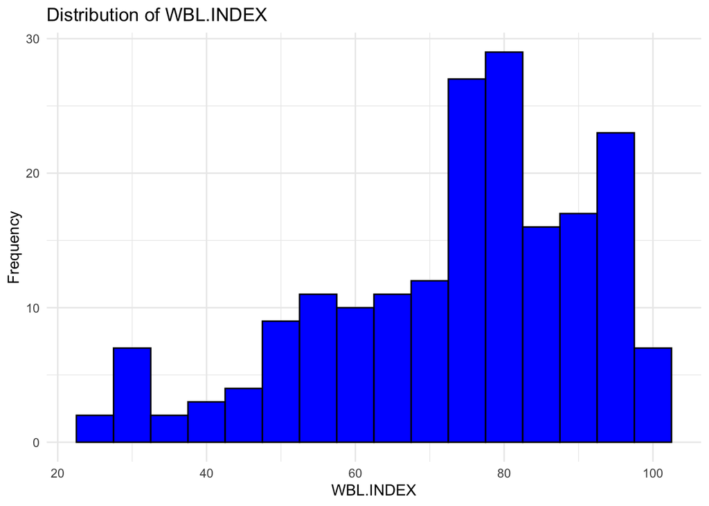

```r
ggplot(economic_indicators_and_gender_inequality_data_subset, aes(x = WBL.INDEX)) +
  geom_histogram(binwidth = 5, fill = "blue", color = "black") +
  theme_minimal() +
  labs(title = "Distribution of WBL.INDEX", x = "WBL.INDEX", y = "Frequency")
```

In the year of 2018, the distribution of WBL.Index presents a left skew with higher frequencies for higher WBL.Index scores than lower WBL.Index score.

WORKPLACE INDEX

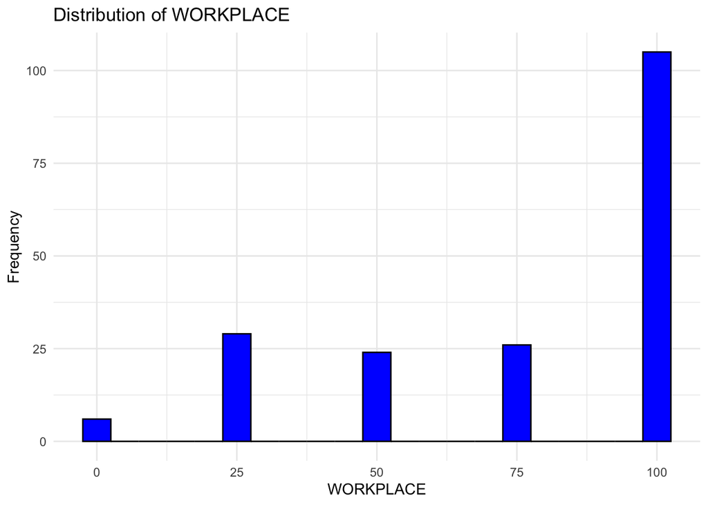

```r
ggplot(economic_indicators_and_gender_inequality_data_subset, aes(x = WORKPLACE)) +
  geom_histogram(binwidth = 5, fill = "blue", color = "black") +
  theme_minimal() +
  labs(title = "Distribution of WORKPLACE", x = "WORKPLACE", y = "Frequency")
```

In the year of 2018, a great majority of the workplace scores were at 100 with the rest spread across the various scores.

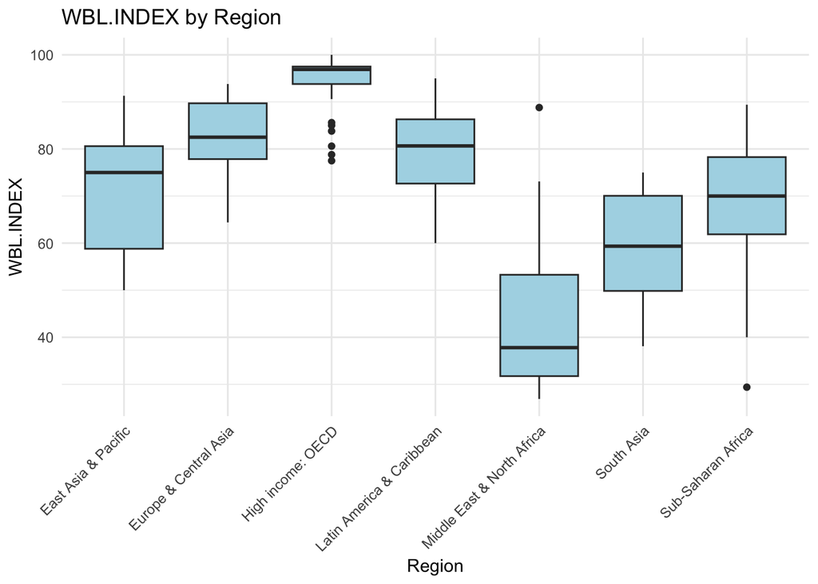

```r
par(mar = c(5, 5, 4, 2))
ggplot(economic_indicators_and_gender_inequality_data_subset, aes(x = Region, y = WBL.INDEX)) +
  geom_boxplot(fill = "lightblue") +
  theme_minimal() +
  labs(title = "WBL.INDEX by Region", x = "Region", y = "WBL.INDEX") +
  theme(axis.text.x = element_text(angle = 45, hjust = 1))
```

Based on regions, Middle East and North Africa seem to have lowest scores for WBL Index and High Income OECD seem to have the highest scores for WBL Index.

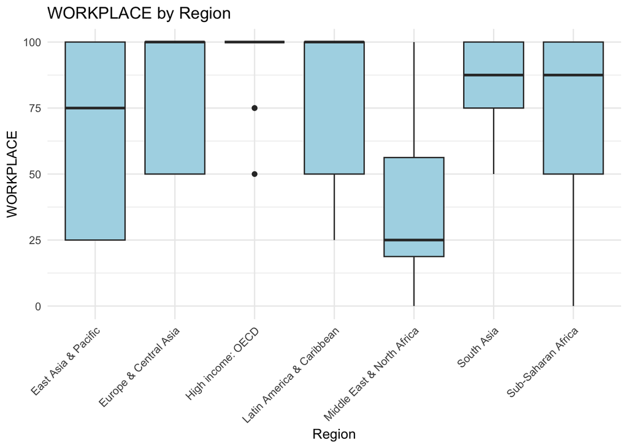

```r
par(mar = c(5, 5, 4, 2))
ggplot(economic_indicators_and_gender_inequality_data_subset, aes(x = Region, y = WORKPLACE)) +
  geom_boxplot(fill = "lightblue") +
  theme_minimal() +
  labs(title = "WORKPLACE by Region", x = "Region", y = "WORKPLACE") +
  theme(axis.text.x = element_text(angle = 45, hjust = 1))
```

Based on regions, Middle East and North Africa seem to have lowest scores for Workplace and High Income OECD seem to have the highest scores for Workplace as well.

```r
economic_indicators_and_gender_inequality_data_subset %>%
  group_by(Region) %>%
  summarize(yes_answer_count = sum(Can.a.woman.get.a.job.in.the.same.way.as.a.man. == "Yes", na.rm = TRUE),
            no_answer_count = sum(Can.a.woman.get.a.job.in.the.same.way.as.a.man. == "No", na.rm = TRUE)) %>%
  mutate(total = yes_answer_count + no_answer_count,
         yes_answer_percentage = yes_answer_count / total * 100)
```

```
# A tibble: 7 × 5
  Region            yes_answer_count no_answer_count total yes_answer_percentage
  <chr>                        <int>           <int> <int>                 <dbl>
1 East Asia & Paci…               25               0    25                 100
2 Europe & Central…               23               0    23                 100
3 High income: OECD               34               0    34                 100
4 Latin America & …               32               0    32                 100
5 Middle East & No…               10              10    20                  50
6 South Asia                       8               0     8                 100
7 Sub-Saharan Afri…               37              11    48                  77.1
```